# Notes 2025-11-10

Blazej Kochanski

2025-11-10

## The data

```r
library(googlesheets4)
gs4_deauth()
d <- read_sheet("https://docs.google.com/spreadsheets/d/1I1ZJ4I345TfaHvyCCgzMz8pMsfS_J3yi9WcpcrhO6No/edit?usp=sharing", "clean_data")
```

```
## ✔ Reading from "Green_DAR2025_data".
```

```
## ✔ Range ''clean_data''.
```

Let’s construct a 95-percent CI (confidence interval) for the mean height. We assume the data we collected is a sample from the population of some students. And we ask ourselves what is the average height in the population.

```r
mean(d$height)
```

```
## [1] 176.9615
```

```r
test_result<-t.test(d$height, conf.level = 0.95)
print(test_result$conf.int)
```

```
## [1] 174.1934 179.7297
## attr(,"conf.level")
## [1] 0.95
```

Compute:

- The confidence interval for the average right hand span in the population (assume 99% confidence).
- The 95-percent confidence interval for the average movies watching time in hours (`movies`).
- The 95-percent confidence interval for the proportion of males in the group.
- The 95-percent confidence interval for the correlation between the height and head size (`head_circ`).

Some templates from my statistics2 course:

https://bookdown.org/blazej_kochanski/statistics2/templates-main.html

The confidence interval for the average right hand span in the population (assume 99% confidence).

```r
mean(d$right_hand_span)
```

```
## [1] 19.95962
```

```r
test_result<-t.test(d$right_hand_span, conf.level = 0.99)
print(test_result$conf.int)
```

```
## [1] 18.99084 20.92839
## attr(,"conf.level")
## [1] 0.99
```

The 95-percent confidence interval for the average movies watching time in hours (`movies`).

```r
mean(d$movies, na.rm=TRUE)
```

```
## [1] 1.387333
```

```r
test_result<-t.test(d$movies, conf.level = 0.95)
print(test_result$conf.int)
```

```
## [1] 1.035888 1.738779
## attr(,"conf.level")
## [1] 0.95
```

The 95-percent confidence interval for the proportion of males in the group.

```r
(nmales = sum(d$gender=="Male"))
```

```
## [1] 34
```

```r
(n = length(d$gender))
```

```
## [1] 52
```

```r
#install.packages("binom")
binom::binom.confint(nmales, n, conf.level = 0.95, method="wilson")
```

```
##   method  x  n      mean     lower     upper
## 1 wilson 34 52 0.6538462 0.5180355 0.7684899
```

```r
prop.test(nmales, n, conf.level = 0.95, correct = FALSE)$conf.int
```

```
## [1] 0.5180355 0.7684899
## attr(,"conf.level")
## [1] 0.95
```

The 95-percent confidence interval for the correlation between the height and head size (`head_circ`).

```r
cor.test(d$height, d$head_circ, alternative = "two.sided", conf.level = 0.95)
```

```
##
##  Pearson's product-moment correlation
##
## data:  d$height and d$head_circ
## t = 5.5442, df = 49, p-value = 1.169e-06
## alternative hypothesis: true correlation is not equal to 0
## 95 percent confidence interval:
##  0.4165683 0.7654829
## sample estimates:
##       cor
## 0.6208758
```

Some templates from my statistics2 course:

https://bookdown.org/blazej_kochanski/statistics2/templates-main.html

## How does randomness look like – experiment

Your job is to imagine 100 tosses of the coin, one after another. One side is “0”, another “1” (Orzel/Reszka; Head/Tail) etc. Put them on paper, using a pen. Without computers or real coins/other random number generators.

Put them in sequence, ten tosses in a line, ten lines. The person, whose tosses are most similar to typical real random tosses wins.

## Testing correlation (association) between two categorical variables

```r
d$eye_colour2 <- d$eye_colour
d$eye_colour2[!(d$eye_colour %in% c("Blue", "Brown", "Green"))] <- "Other"
tab <- table(d$gender, d$eye_colour2)
tab
```

```
##
##          Blue Brown Green Other
##   Female    6     8     1     3
##   Male     12    10     9     3
```

```r
vcd::assocstats(tab)$cramer
```

```
## [1] 0.2803152
```

$H_0$: There is no dependency between gender and eye colour.

$H_A$: There is dependency between gender and eye colour.

Chi-square test.

```r
chisq.test(tab)
```

```
##
##  Pearson's Chi-squared test
##
## data:  tab
## X-squared = 4.086, df = 3, p-value = 0.2523
```

```r
chisq.test(table(d$gender, d$eye_colour2))
```

```
##
##  Pearson's Chi-squared test
##
## data:  table(d$gender, d$eye_colour2)
## X-squared = 4.086, df = 3, p-value = 0.2523
```

## Bootstrapping

Universal simulation-based tool to obtain the confidence interval for a population parameter from a sample.

Let’s construct a 95-percent CI (confidence interval) for the mean height in population with bootstrapping.

We have a sample of n=52 and we create 10000 of size n=52 (these are bootstrap samples). In each bootstrap sample we compute the mean. We have a distribution of those means and we can get a confidence interval from this distribution.

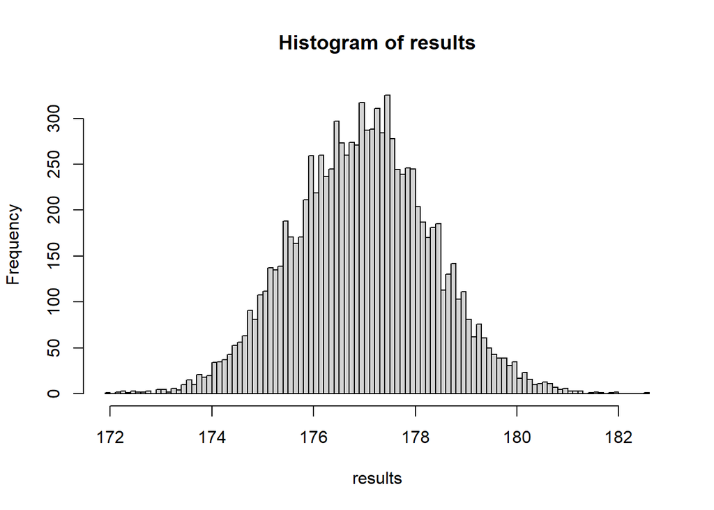

```r
orig <- d$height
nsim <- 1e4
results <- replicate(nsim,
                     {boot <- sample(orig, length(orig), replace = TRUE)
                      mean(boot)}
                     )
hist(results, breaks=100)
```

We can get the confidence interval for the mean using the quantiles of the simulated distribution. For the 95-percent distribution you take quantiles 2.5% (0,025) and 100%-2.5% (0.975).

```r
quantile(results, c(0.025, 0.975))
```

```
##     2.5%    97.5%
## 174.3269 179.6731
```